# Car Selling Price

```r
library(readr)
library(pander)
library(DT)
library(car)
library(mosaic)
library(MASS)
Car_Analysis <- read_csv("~/Desktop/Files/Undergrad/Analysis Tools/Intermediate Stats Notebook/Data/Car_Analysis.csv")
reg <- lm(Price ~ Mileage, data = Car_Analysis)
reg2 <- lm(sqrt(Price) ~ Mileage, data = Car_Analysis)
```

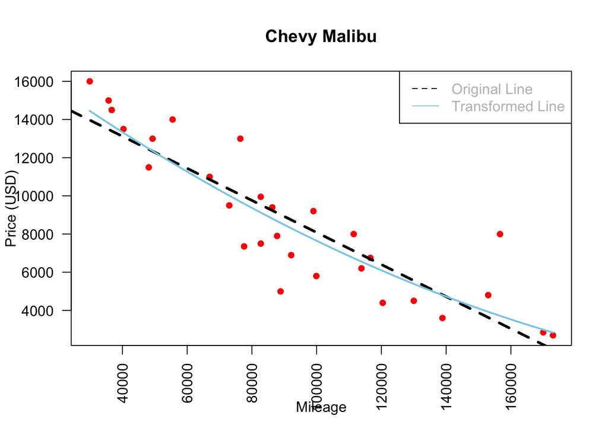

```r
plot(Price ~ Mileage, data = Car_Analysis, pch = 16, col = "red", las = 2, ylab = "Price (USD)", main = "Chevy Malibu")
abline(reg, lty = 2, lwd = 3)
curve(((134.2 - 0.0004676 * x)^2), add = TRUE, col = "skyblue", lwd = 2)
legend("topright", legend = c("Original Line", "Transformed Line"), text.col = "grey", lty = c(2,1), col = c("black", "skyblue"))
```

## Background

My first car ever purchased was kind of a train wreck! It’s a 2010 silver Malibu LT back in 2013. It had 58,000 miles on it with a price tag of $13,300. I was severely unprepared in dealing with the purchase of my first car. Along with the lack of valuable research that *should* have gone into the biggest purchase of my life at that point, it didn’t help that I am a sucker for a cute blonde with a nice smile. As soon as I left the dealership, I pulled up KSL to find out that the exact car with, the exception of the color, was priced for three thousand dollars less than what I had paid for; and what’s worse… I didn’t even get the girls number. What a sham.

For this analysis I will focus on the the effects of mileage has on the price of the car with the same model of my Malibu. To expand my dataset from the 17 observations found, I allowed different colors and allowing the year from 2005 to 2015. This gave me the 29 observations within the data set which is posted below.

The null hypotheses will state that not only the intercept but also the mileage will hold no significant effect on the price of the car. The critical value will be set to $\alpha = 0.05$. Formally put:
$$H_0: \beta_1 = 0$$
$$H_a: \beta_1 \neq 0$$

## Original Summary Data

```r
pander(summary(reg))
```

|  | Estimate | Std. Error | t value | Pr(>\|t\|) |
| --- | --- | --- | --- | --- |
| **(Intercept)** | 16480 | 877.4 | 18.78 | 4.97e-17 |
| **Mileage** | -0.08399 | 0.008683 | -9.673 | 2.882e-10 |

Fitting linear model: Price ~ Mileage

| Observations | Residual Std. Error | $R^2$ | Adjusted $R^2$ |
| --- | --- | --- | --- |
| 29 | 1863 | 0.7761 | 0.7678 |

$$\hat{Y}_i = 16480 - 0.08399\underbrace{X_i}_{Mileage}$$

### Diagnostic Plots: Original

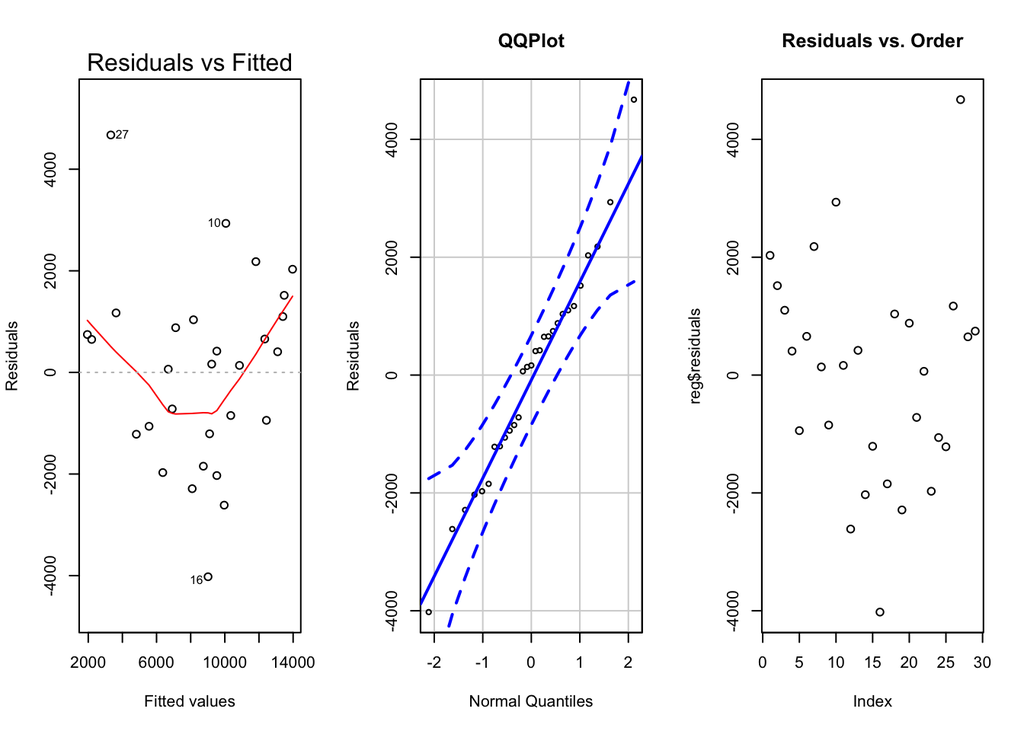

```r
par(mfrow = c(1,3))
plot(reg, which = 1)
qqPlot(reg$residuals, id = FALSE, ylab = "Residuals", xlab = "Normal Quantiles", main = "QQPlot")
plot(reg$residuals, main = "Residuals vs. Order")
```

## Box-Cox Transformation

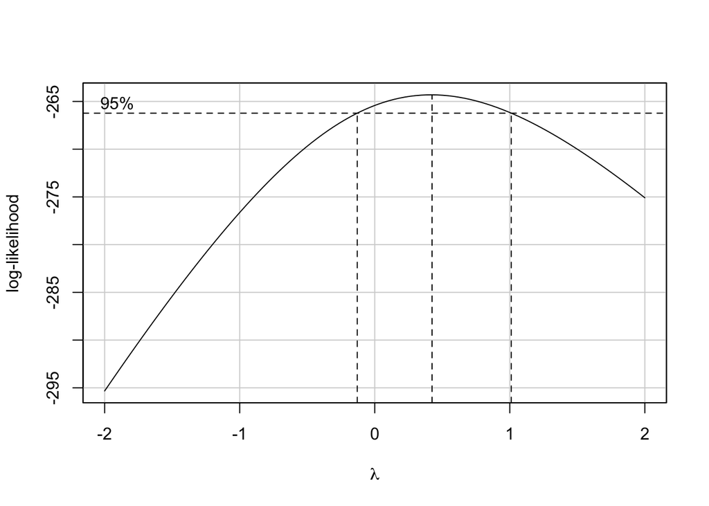

```r
boxCox(reg)
```

The Box-Cox shows a $\lambda$ of 0.5. This suggests that the correct trasformation for the dataset is the square root of `Price`.

## Transformed Summary Data

```r
pander(summary(reg2))
```

|  | Estimate | Std. Error | t value | Pr(>\|t\|) |
| --- | --- | --- | --- | --- |
| **(Intercept)** | 134.2 | 4.671 | 28.73 | 8.856e-22 |
| **Mileage** | -0.0004676 | 4.623e-05 | -10.12 | 1.109e-10 |

Fitting linear model: sqrt(Price) ~ Mileage

| Observations | Residual Std. Error | $R^2$ | Adjusted $R^2$ |
| --- | --- | --- | --- |
| 29 | 9.918 | 0.7912 | 0.7835 |

$$\hat{Y}_i' = (134.2 - 0.0004676\underbrace{X_i}_\text{Mileage of Car})^2$$

### Diagnostic Plots: Transformed

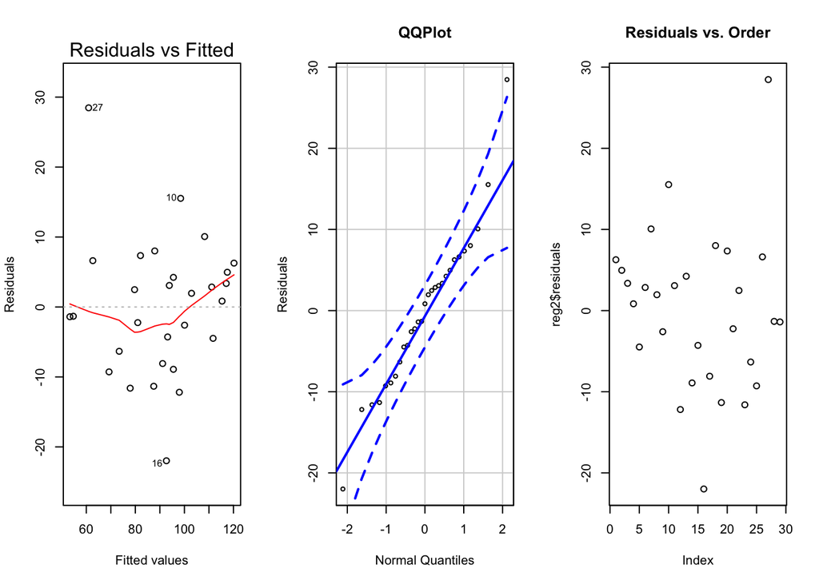

```r
par(mfrow = c(1,3))
plot(reg2, which = 1)
qqPlot(reg2$residuals, id = FALSE, ylab = "Residuals", xlab = "Normal Quantiles", main = "QQPlot")
plot(reg2$residuals, main = "Residuals vs. Order")
```

## Data Table

```r
datatable(Car_Analysis)
```

|  | Make | Model | Trim | Year | Mileage | Price | Color |
| --- | --- | --- | --- | --- | --- | --- | --- |
| 1 | Chevrolet | Malibu | LT | 2015 | 29909 | 15999 | Red |
| 2 | Chevrolet | Malibu | LT | 2015 | 35744 | 14995 | Red |
| 3 | Chevrolet | Malibu | LT | 2015 | 36692 | 14498 | Red |
| 4 | Chevrolet | Malibu | LT | 2014 | 40320 | 13500 | Silver |
| 5 | Chevrolet | Malibu | LT | 2015 | 48146 | 11493 | Silver |
| 6 | Chevrolet | Malibu | LT | 2013 | 49314 | 12995 | Silver |
| 7 | Chevrolet | Malibu | LT | 2015 | 55500 | 13999 | White |
| 8 | Chevrolet | Malibu | LT | 2014 | 66943 | 10995 | Black |
| 9 | Chevrolet | Malibu | LT | 2012 | 73000 | 9500 | Black |
| 10 | Chevrolet | Malibu | LT | 2015 | 76424 | 12995 | White |

[output cut: 19 more lines]

### Conclusion & Comparison

There is some concern of the variance as it appears to be bowing out and then back in, implying unconstant varivance.

The predicted value of my car at purchase would be:  
$Original \space Prediction:$

```r
pander(predict(reg, list(Mileage = 58000)))
```

| 1 |
| --- |
| 11608 |

$Square \space Root \space Prediciton:$

```r
pander(predict(reg2, list(Mileage = 58000))^2)
```

| 1 |
| --- |
| 11467 |